# Data Analysis Workshop-Predicting Penguin Body Mass

Joy Liu

2026-05-25

## 1. Introduction

In this analysis, we aim to predict penguin body mass (*body_mass_g*) using morphological measurements such as bill length, bill depth, and flipper length from the palmerpenguins dataset. Understanding variation in body mass is important because it reflects ecological adaptation, foraging ability, and energetic constraints across species living in different environmental conditions.

The dataset includes three penguin species—Adelie, Chinstrap, and Gentoo (see Figure 1)—which differ in body size and morphology. These species are sampled from three islands in the Palmer Archipelago (Biscoe, Dream, and Torgersen; see Figure 2), a region in Antarctica where environmental conditions and habitat characteristics vary spatially.

We will use statistical modelling approaches, including multiple linear regression and potentially generalized linear mixed models, to quantify the relationship between body mass and morphological predictors. The goal is to build an interpretable model that explains variation in body mass while allowing meaningful ecological interpretation of each predictor.

Overall, this analysis aims not only to produce accurate predictions of body mass but also to provide ecological insight into how morphology and habitat jointly shape penguin body condition.

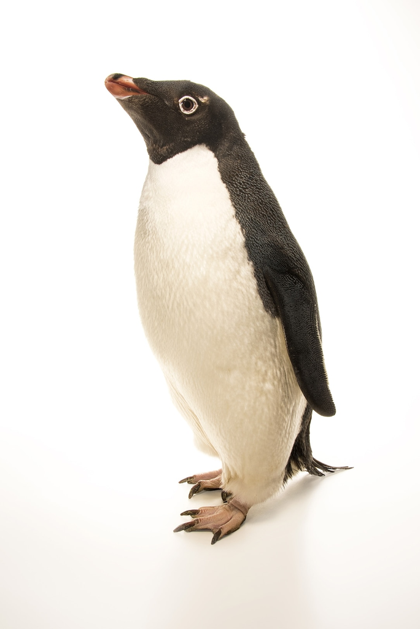

**(a)** Adelie

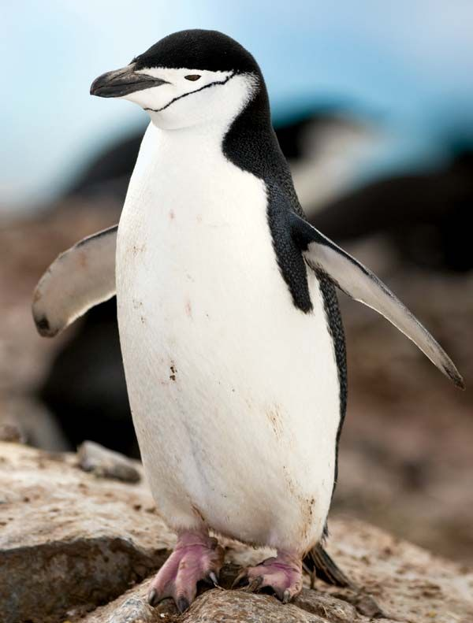

**(b)** Chinstrap

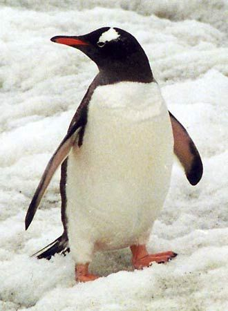

**(c)** Gentoo

**Figure 1.** Penguin species comparison: (a) Adelie, (b) Chinstrap, and (c) Gentoo.

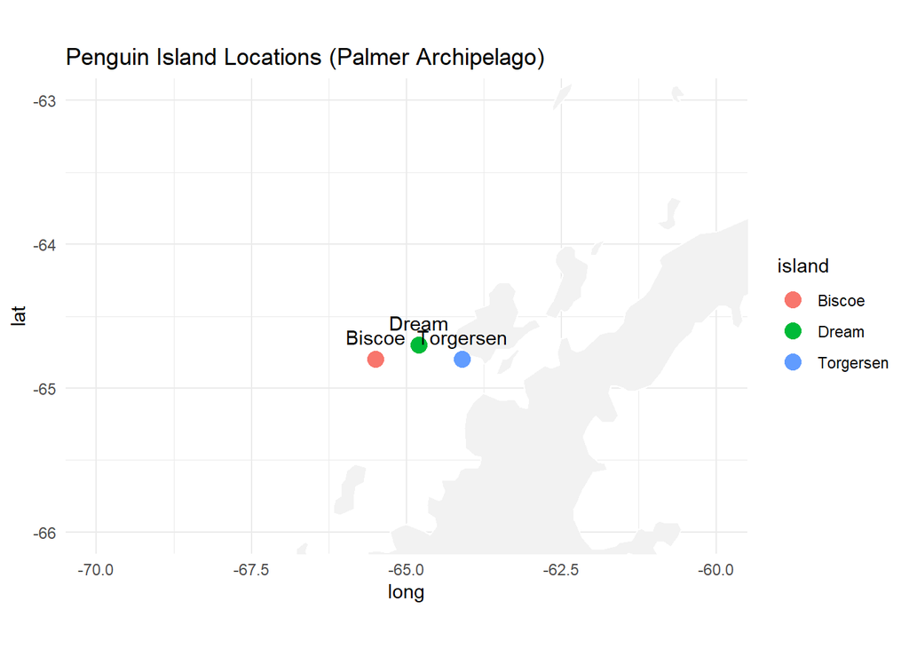

Figure 2. Penguin island sampling locations in the Palmer Archipelago (Biscoe, Dream, and Torgersen Islands).

## 3. Exploratory Data Analysis (EDA)

The data used in this analysis come from the palmerpenguins dataset, which is a simplified and curated version of field observations originally collected as part of ecological research in Antarctica. The measurements were taken on penguin colonies located in the Palmer Archipelago between 2007 and 2009 by researchers from the Palmer Station Long-Term Ecological Research (LTER) program.

Data collection involved direct, on-site biological sampling of wild penguins. Researchers captured individual birds briefly to record physical measurements such as body mass (body_mass_g), flipper length, bill length, and bill depth. Body mass was measured using field scales, while morphological traits were measured using calipers. After measurements were taken, the penguins were released back to their colonies. This hands-on sampling approach is standard in ecological fieldwork but requires careful handling to minimize stress on the animals.

```r
# Load Libraries
library(tidyverse)
library(dplyr)
library(ggplot2)
library(tidyr)
library(palmerpenguins)
library(ggthemes)
library(GGally)
library(corrplot)
library(gridExtra)
library(maps)
library(glmmTMB)
library(see)
library(rsample)
library(purrr)
library(Metrics)
library(performance)
library(ggeffects)
```

```r
# Load and Clean Data
penguins  <- penguins %>%
  drop_na() %>%
  mutate(year = as.factor(year))

# Note: in general, you need to explain your data wrangling process before EDA. For dealing with missing values, there're many strategies. Here we only have 2 (over 333 observations), we can drop them,
```

```r
# Summarize Data
summary(penguins)
```

```
##       species          island    bill_length_mm  bill_depth_mm
##  Adelie   :146   Biscoe   :163   Min.   :32.10   Min.   :13.10
##  Chinstrap: 68   Dream    :123   1st Qu.:39.50   1st Qu.:15.60
##  Gentoo   :119   Torgersen: 47   Median :44.50   Median :17.30
##                                  Mean   :43.99   Mean   :17.16
##                                  3rd Qu.:48.60   3rd Qu.:18.70
##                                  Max.   :59.60   Max.   :21.50
##  flipper_length_mm  body_mass_g       sex        year
##  Min.   :172       Min.   :2700   female:165   2007:103
##  1st Qu.:190       1st Qu.:3550   male  :168   2008:113
##  Median :197       Median :4050                2009:117
##  Mean   :201       Mean   :4207
##  3rd Qu.:213       3rd Qu.:4775
##  Max.   :231       Max.   :6300
```

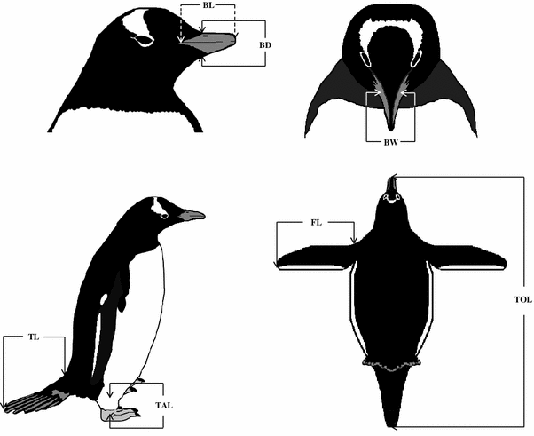

**Bill morphology (Valenzuela-Guerra, etc., 2013)**

**Figure 3.** Penguin morphological predictors.

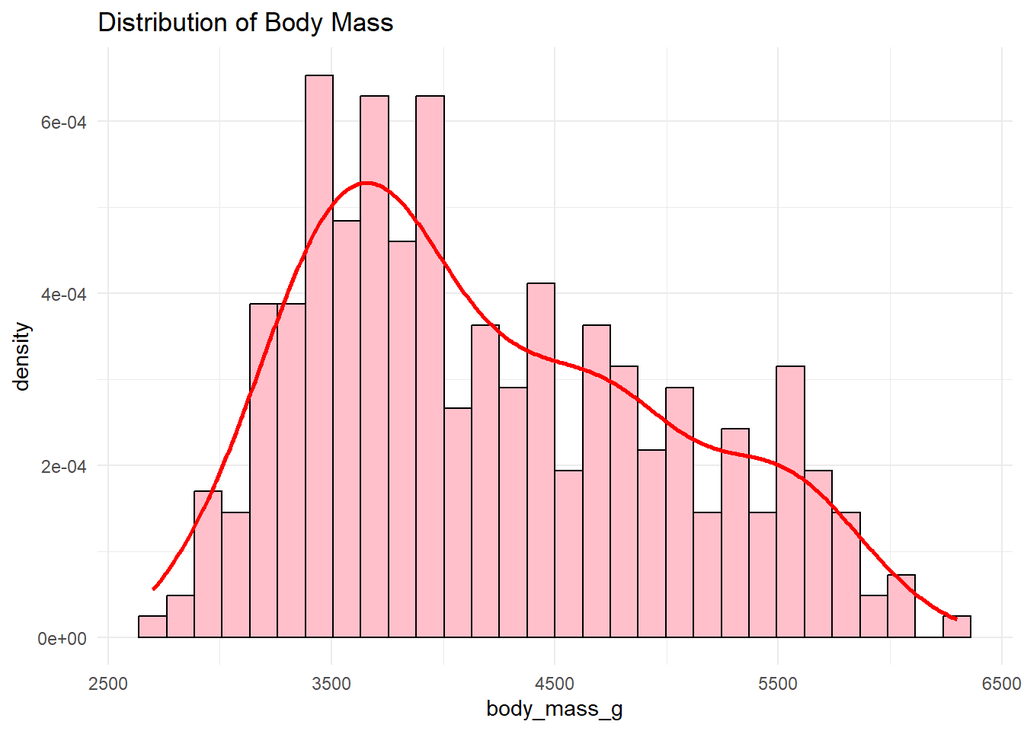

Figure 4. Distribution of Body Mass

```r
# Distribution of Body Mass
p1 <- ggplot(penguins, aes(x = body_mass_g)) +
  geom_histogram(aes(y = ..density..),
                 bins = 30,
                 fill = "pink",
                 color = "black") +
  geom_density(color = "red", linewidth = 1) +
  labs(title = "Distribution of Body Mass") +
  theme_minimal()
p1
```

```r
# Body Mass by Species
p2= ggplot(penguins, aes(x = species, y = body_mass_g, fill = species)) +
  geom_boxplot() +
  labs(title = "Body Mass by Species")

# Body Mass by Years
p3= ggplot(penguins, aes(x = year, y = body_mass_g, fill = year)) +
  geom_boxplot() +
  labs(title = "Body Mass by Year", x = "Year")

# Body Mass by flipper_length
p4= ggplot(penguins, aes(x = flipper_length_mm, y = body_mass_g)) +
  geom_point(alpha = 0.6,color = "steelblue") +
  labs(title = "Body Mass vs Flipper Length",
       x = "Flipper Length (mm)",
       y = "Body Mass (g)") +
  theme_minimal()

# Body Mass by bill_length_mm
p5= ggplot(penguins, aes(x = bill_length_mm, y = body_mass_g)) +
  geom_point(alpha = 0.6, color = "darkgreen") +
  labs(title = "Body Mass vs Bill length",
       x = "Bill length (mm)",
       y = "Body Mass (g)") +
  theme_minimal()

# Body Mass by bill_depth_mm
p6= ggplot(penguins, aes(x = bill_depth_mm, y = body_mass_g)) +
  geom_point(alpha = 0.6, color = "purple") +
  labs(title = "Body Mass vs Bill depth",
       x = "Bill depth (mm)",
       y = "Body Mass (g)") +
  theme_minimal()

# Body Mass by island
p7=  ggplot(penguins, aes(x = island, y = body_mass_g, fill = island)) +
  geom_boxplot() +
  labs(title = "Body Mass by Island")


# Body Mass by sex
p8=  ggplot(penguins, aes(x = sex, y = body_mass_g, fill = sex)) +
  geom_boxplot() +
  labs(title = "Body Mass by Sex") +
  theme_minimal() +
  theme(legend.position = "none")
```

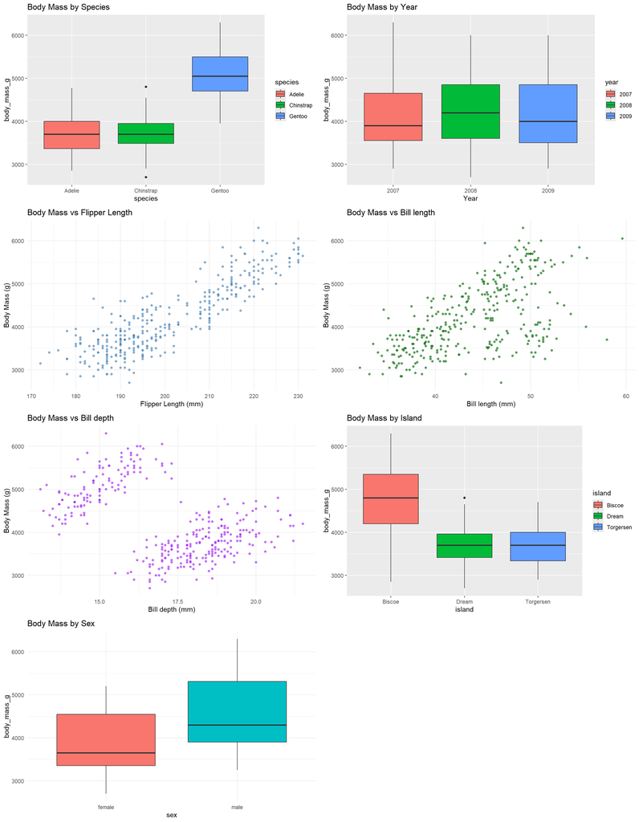

Figure 5. Explanatory Varaiables vs Response

```r
grid.arrange(
  p2, p3,
  p4, p5, p6,
  p7, p8,
  ncol = 2
)
```

### Correlation Check

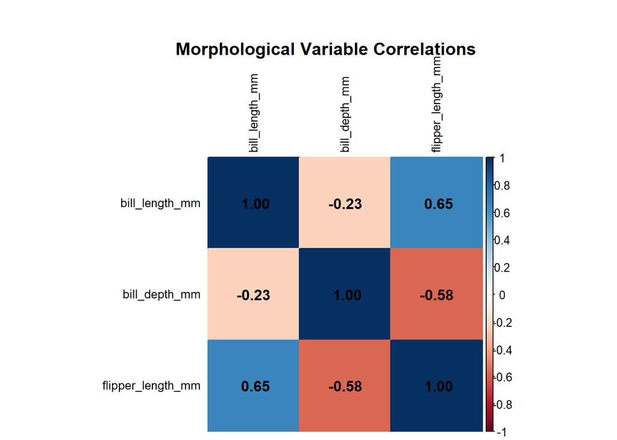

Figure 6. Explanatory Multicollinearity

```r
numeric_data <- penguins[, c("bill_length_mm",
                             "bill_depth_mm",
                             "flipper_length_mm")]

corr_matrix <- cor(numeric_data,
                   method = "pearson",
                   use = "pairwise.complete.obs")

corrplot(corr_matrix,
         method = "color",
         addCoef.col = "black",
         mar = c(0,0,3,0),
         tl.col = "black",
         tl.cex = 0.8)

title("Morphological Variable Correlations", line = 1)
```

From the initial exploratory data analysis (EDA), we observe that both species and island are imbalanced in the palmerpenguins dataset. For example, only 47 observations come from Torgersen Island, while the majority of penguins are sampled from Biscoe and Dream. This imbalance is important because it can influence model training and evaluation if not properly accounted for.

We also observe that the morphological variables—bill length, bill depth, and flipper length—are measured on different scales. This means that variables with larger numerical ranges could dominate model fitting, especially in methods sensitive to scale (e.g., penalized regression or distance-based approaches). To address this, we standardize the continuous predictors so that each variable has mean 0 and standard deviation 1.

From the correlation heatmap (Fig. 6) , we observe no evidence of severe multicollinearity among the continuous morphological predictors, as pairwise correlations remain below the common rule-of-thumb threshold of 0.7. This suggests that bill length, bill depth, and flipper length can reasonably be included together in the modelling framework without major concern for unstable coefficient estimation.

The histogram (Fig. 4) of body mass indicates a moderate right-skewed distribution, suggesting that while linear modelling may still be appropriate, model assumptions related to normality should be carefully evaluated through residual diagnostics.

Additionally, visible clustering by species and island suggests the presence of underlying group structure within the data. These grouping effects likely reflect biological and ecological differences among penguin populations and should be accounted for in the model through categorical predictors or hierarchical modelling approaches.

```r
# Data Scaling
penguins[, c("bill_length_std",
             "bill_depth_std",
             "flipper_length_std")] <-
  scale(penguins[, c("bill_length_mm",
                     "bill_depth_mm",
                     "flipper_length_mm")])
summary(penguins)
```

```
##       species          island    bill_length_mm  bill_depth_mm
##  Adelie   :146   Biscoe   :163   Min.   :32.10   Min.   :13.10
##  Chinstrap: 68   Dream    :123   1st Qu.:39.50   1st Qu.:15.60
##  Gentoo   :119   Torgersen: 47   Median :44.50   Median :17.30
##                                  Mean   :43.99   Mean   :17.16
##                                  3rd Qu.:48.60   3rd Qu.:18.70
##                                  Max.   :59.60   Max.   :21.50
##  flipper_length_mm  body_mass_g       sex        year     bill_length_std
##  Min.   :172       Min.   :2700   female:165   2007:103   Min.   :-2.17471
##  1st Qu.:190       1st Qu.:3550   male  :168   2008:113   1st Qu.:-0.82155
##  Median :197       Median :4050                2009:117   Median : 0.09275
##  Mean   :201       Mean   :4207                           Mean   : 0.00000
##  3rd Qu.:213       3rd Qu.:4775                           3rd Qu.: 0.84247
##  Max.   :231       Max.   :6300                           Max.   : 2.85393
##  bill_depth_std     flipper_length_std
##  Min.   :-2.06418   Min.   :-2.0667
##  1st Qu.:-0.79466   1st Qu.:-0.7825
##  Median : 0.06862   Median :-0.2830
##  Mean   : 0.00000   Mean   : 0.0000
##  3rd Qu.: 0.77956   3rd Qu.: 0.8585
##  Max.   : 2.20143   Max.   : 2.1428
```

## 4. Model Selection

### Multiple linear regression model:

$$\begin{align*}
y = \beta X + \epsilon \\
y \sim N(\mu,\sigma^2) \\
\end{align*}$$

```r
model <- lm(body_mass_g ~ bill_length_std + bill_depth_std + flipper_length_std+ species + island + year + sex, data = penguins)
summary(model)
```

```
##
## Call:
## lm(formula = body_mass_g ~ bill_length_std + bill_depth_std +
##     flipper_length_std + species + island + year + sex, data = penguins)
##
## Residuals:
##     Min      1Q  Median      3Q     Max
## -811.78 -184.10   -3.31  181.94  860.05
##
## Coefficients:
##                    Estimate Std. Error t value Pr(>|t|)
## (Intercept)         3820.85      91.91  41.572  < 2e-16 ***
## bill_length_std      102.35      39.34   2.602  0.00970 **
## bill_depth_std       118.69      39.67   2.992  0.00299 **
## flipper_length_std   261.47      44.75   5.843 1.26e-08 ***
## speciesChinstrap    -281.02      89.13  -3.153  0.00177 **
## speciesGentoo        886.69     145.80   6.081 3.37e-09 ***
## islandDream          -22.61      58.76  -0.385  0.70070
## islandTorgersen      -59.77      61.07  -0.979  0.32848
## year2008             -51.80      42.16  -1.229  0.22011
## year2009             -86.65      42.19  -2.054  0.04079 *
## sexmale              379.64      48.22   7.873 5.33e-14 ***
## ---
## Signif. codes:  0 '***' 0.001 '**' 0.01 '*' 0.05 '.' 0.1 ' ' 1
##
## Residual standard error: 286.9 on 322 degrees of freedom
## Multiple R-squared:  0.8768, Adjusted R-squared:  0.873
## F-statistic: 229.2 on 10 and 322 DF,  p-value: < 2.2e-16
```

### LM Interpretation:

This multiple linear regression model predicts penguin body mass (body_mass_g) using standardized morphological traits, species, island, year, and sex. Overall, the model performs very well and explains a substantial proportion of variation in body mass.

#### Overall model performance

The model explains approximately 87.7% of the variation in penguin body mass (Multiple R² = 0.8768; Adjusted R² = 0.873), indicating excellent explanatory power. The high F-statistic (229.2, p < 2.2e-16) suggests that the full model is highly significant overall, meaning the included predictors collectively provide strong predictive value compared to a null model.

The residual standard error is approximately 287 g, meaning that, on average, predicted body mass differs from observed values by about 287 grams.

#### Interpretation of R outputs

Intercept: (3820.85 g) represents the predicted body mass for the baseline penguin:

- Adelie species
- Biscoe Island
- Year 2007
- Female
- Average standardized bill length, bill depth, and flipper length (all = 0)

##### Continuous standardized morphological variables

Because bill length, bill depth, and flipper length were standardized, each coefficient represents the expected body mass change associated with a one standard deviation increase in that variable.

- Bill length: A 1 SD increase in bill length is associated with an average increase of 102.35 g in body mass, holding other variables constant (p = 0.0097).
- Bill depth: A 1 SD increase in bill depth is associated with an average increase of 118.69 g in body mass (p = 0.0030).
- Flipper length: A 1 SD increase in flipper length is associated with an average increase of 261.47 g in body mass (p < 0.001), making it the strongest continuous morphological predictor in the model.

##### Discrete variables

- Species effects: Using Adelie penguins as the reference category

Chinstrap penguins weigh, on average, 281 g less than Adelie penguins after accounting for morphology and other factors (p = 0.0018). Gentoo penguins weigh approximately 887 g more than Adelie penguins (p < 0.001), indicating substantial species-level differences.

- Island effects: Using Biscoe Island as the reference

Dream Island and Torgersen Island do not significantly differ from Biscoe in body mass after controlling for other predictors (p > 0.3).

This suggests that island-specific effects may largely be captured through species and morphology rather than direct location effects.

- Year effects: Using 2007 as the baseline

Penguins measured in 2008 do not differ significantly from 2007. Penguins in 2009 are predicted to weigh about 87 g less than those in 2007 (p = 0.041), though this effect is relatively small.

- Sex effect: Using female penguins as the baseline

Male penguins weigh approximately 380 g more than females on average (p < 0.001), indicating strong sexual dimorphism.

### Residual Plot

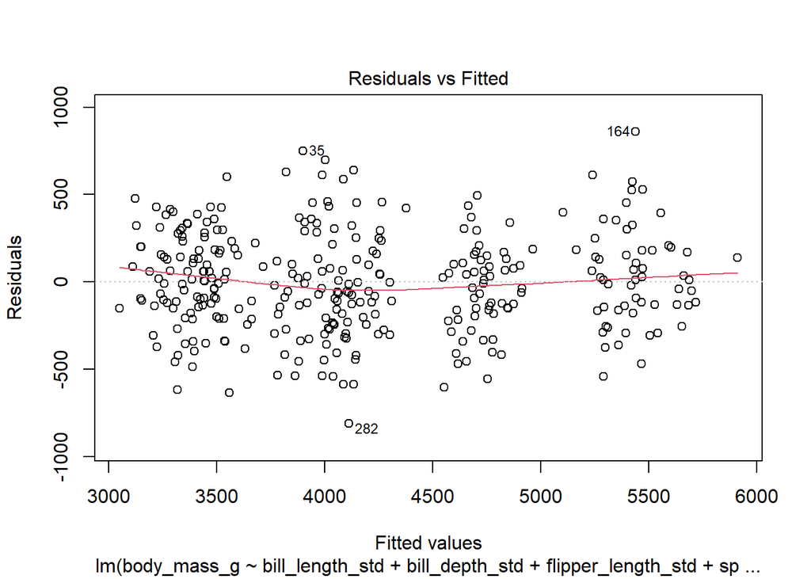

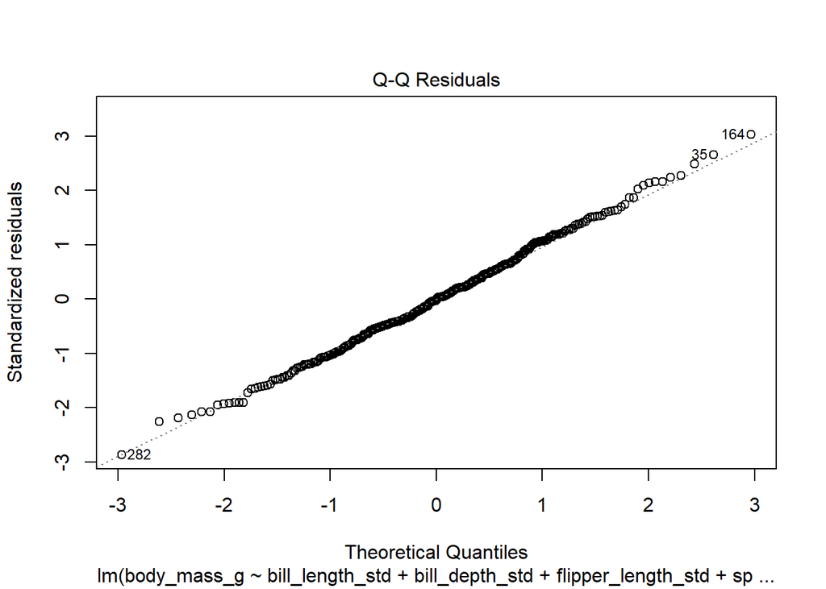

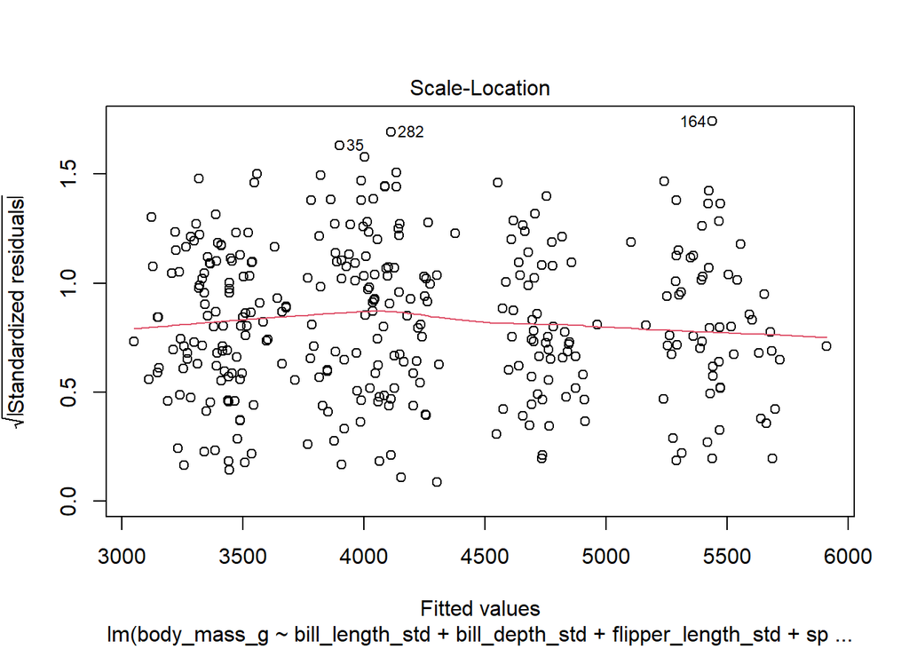

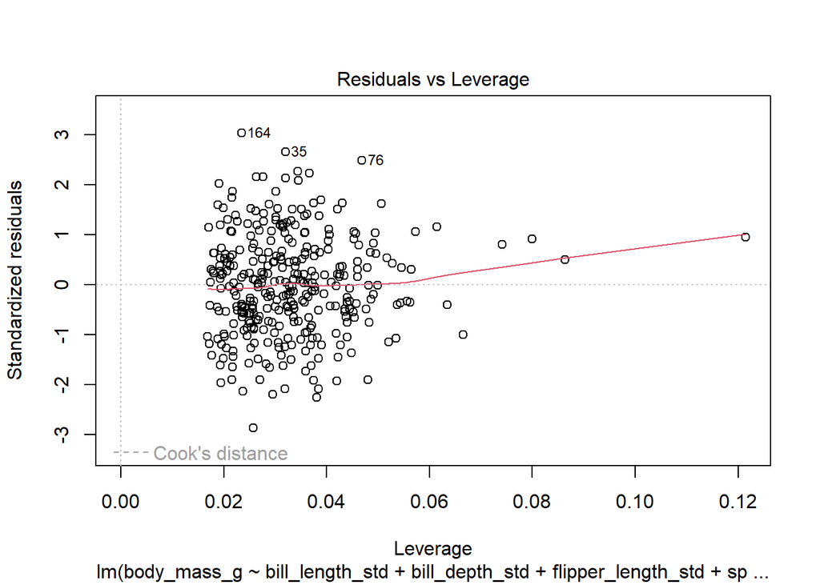

```r
plot(model)
```

```r
penguins$lmresid <- residuals(model)

q1 <- ggplot(penguins, aes(x = bill_length_std, y = lmresid)) +
  geom_point(alpha = 0.6) +
  geom_hline(yintercept = 0, linetype = "dashed") +
  theme_minimal() +
  labs(title = "Residuals vs Bill Length")

q2 <- ggplot(penguins, aes(x = bill_depth_std, y = lmresid)) +
  geom_point(alpha = 0.6) +
  geom_hline(yintercept = 0, linetype = "dashed") +
  theme_minimal() +
  labs(title = "Residuals vs Bill Depth")

q3 <- ggplot(penguins, aes(x = flipper_length_std, y = lmresid)) +
  geom_point(alpha = 0.6) +
  geom_hline(yintercept = 0, linetype = "dashed") +
  theme_minimal() +
  labs(title = "Residuals vs Flipper Length")

q4 <- ggplot(penguins, aes(x = species, y = lmresid)) +
  geom_boxplot() +
  theme_minimal() +
  labs(title = "Residuals vs Species")

q5 <- ggplot(penguins, aes(x = island, y = lmresid)) +
  geom_boxplot() +
  theme_minimal() +
  labs(title = "Residuals vs Island")

q6 <- ggplot(penguins, aes(x = sex, y = lmresid)) +
  geom_boxplot() +
  theme_minimal() +
  labs(title = "Residuals vs Sex")

q7 <- ggplot(penguins, aes(x = factor(year), y = lmresid)) +
  geom_boxplot() +
  theme_minimal() +
  labs(title = "Residuals vs Year")
```

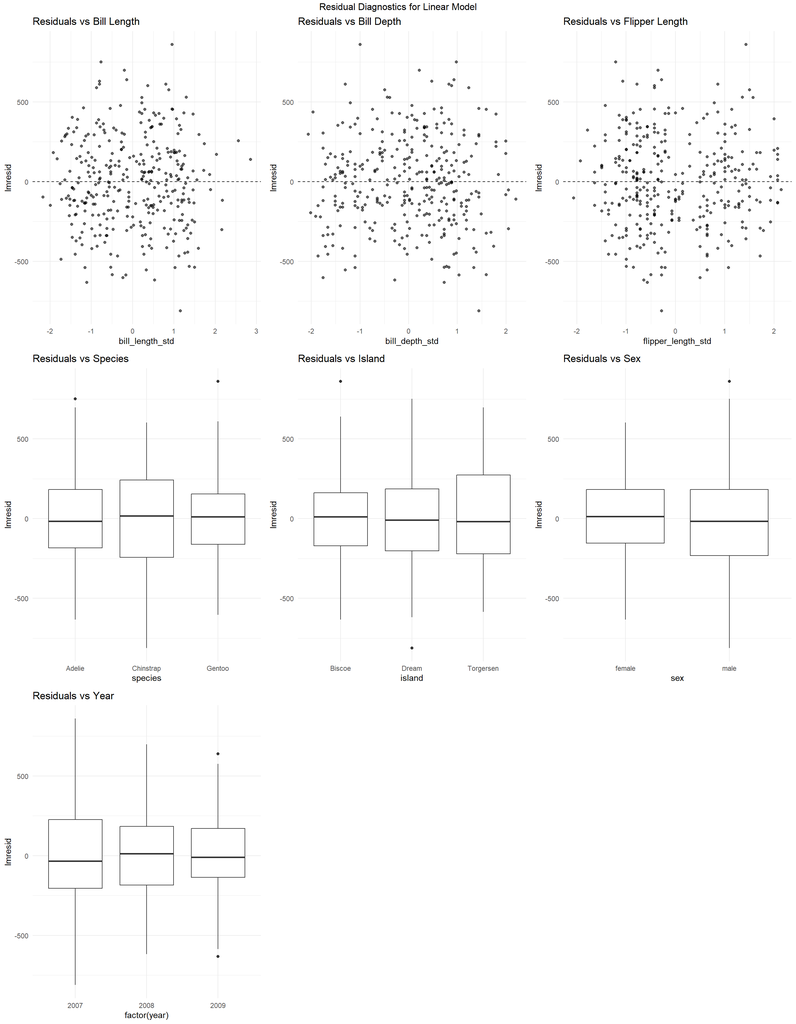

Fig.7. Residual Diagnostics for Linear Model

```r
grid.arrange(
  q1, q2, q3,
  q4, q5, q6, q7,
  ncol = 3,
  top = "Residual Diagnostics for Linear Model"
)
```

1. Residuals vs Fitted Values

The residuals are generally centered around zero, which is desirable; however, visible clustering patterns appear around certain fitted value ranges rather than a completely random scatter. This suggests that the model may not fully capture underlying subgroup structure in the data, likely due to species or sex differences, and may indicate remaining nonlinear effects or omitted interactions.

2. Normal Q-Q Plot

The Q-Q plot shows that residuals deviate moderately from the reference line in the upper tail, indicating slight right-skewness. While the residual distribution is reasonably close to normal overall, this pattern suggests mild departures from the normality assumption, particularly among larger positive residuals.

3. Scale-Location Plot

The Scale-Location plot also shows clustering rather than uniform spread, suggesting that residual variance may differ across fitted values. This may indicate mild heteroscedasticity, where prediction error is not perfectly constant across all body mass ranges.

4. Residuals vs Leverage Plot

The leverage plot indicates the presence of several observations with relatively high leverage, meaning certain penguins may exert disproportionate influence on coefficient estimates. Additionally, curvature in the trend line suggests potential model misspecification or nonlinear relationships not fully addressed by the current linear structure.

Overall Interpretation

These diagnostics suggest that although the model explains body mass well, there may still be:

- Mild nonlinearity
- Group-based clustering
- Slight heteroscedasticity
- Some influential observations

Practical Implications

The current model remains interpretable and strong, but future improvements could include:

- Response variable’s distribution and/or link function
- Random effect (e.g., species, sex, island)

### Generalized linear model:

The residual diagnostics and EDA both suggest that the assumption of simple linearity may not fully capture the biological relationship between penguin morphology and body mass. In many biological systems, body mass often follows an allometric scaling relationship with body size, commonly expressed as:

$$\log(\text{body mass}) = a \log(\text{body size}) + b$$

where *a* represents the scaling exponent and *b* is the intercept. This log-log relationship reflects how mass tends to increase nonlinearly with structural size measurements such as bill length or flipper length.

Because of this biological principle, applying a generalized linear modelling framework with a Gaussian family and log link function may better capture the multiplicative relationship between morphology and body mass while improving model assumptions such as normality and heteroscedasticity.

By modelling body mass on the log scale, we may achieve:

- Improved linearity between predictors and response
- Reduced right-skewness in residuals
- More stable variance across fitted values
- Better biological interpretability through allometric scaling

Therefore, incorporating biologically informed transformations or a GLM with a log link may provide a more appropriate modelling framework for penguin body mass prediction than a standard linear model.

$$\begin{align*}
log(y)= \beta log(X) + \epsilon \\
y \sim N(\mu,\sigma^2) \\
\end{align*}$$

```r
#  Log-transform first, then standardize continuous predictors
penguins[, c("lg_bill_length_std",
             "lg_bill_depth_std",
             "lg_flipper_length_std")] <-
  scale(log(penguins[, c("bill_length_mm",
                         "bill_depth_mm",
                         "flipper_length_mm")]))
```

```r
model2=glmmTMB(body_mass_g ~ lg_bill_length_std + lg_bill_depth_std + lg_flipper_length_std+ species + island + year + sex,family = gaussian(link = "log"), data = penguins)

summary(model2)
```

```
##  Family: gaussian  ( log )
## Formula:
## body_mass_g ~ lg_bill_length_std + lg_bill_depth_std + lg_flipper_length_std +
##     species + island + year + sex
## Data: penguins
##
##       AIC       BIC    logLik -2*log(L)  df.resid
##    4721.0    4766.7   -2348.5    4697.0       321
##
##
## Dispersion estimate for gaussian family (sigma^2): 7.82e+04
##
## Conditional model:
##                        Estimate Std. Error z value Pr(>|z|)
## (Intercept)            8.242914   0.021924   376.0  < 2e-16 ***
## lg_bill_length_std     0.025691   0.009317     2.8  0.00583 **
## lg_bill_depth_std      0.029048   0.009573     3.0  0.00241 **
## lg_flipper_length_std  0.057457   0.010445     5.5 3.78e-08 ***
## speciesChinstrap      -0.071551   0.021825    -3.3  0.00104 **
## speciesGentoo          0.204123   0.034839     5.9 4.66e-09 ***
## islandDream           -0.006675   0.015360    -0.4  0.66388
## islandTorgersen       -0.016766   0.015990    -1.0  0.29438
## year2008              -0.014056   0.009517    -1.5  0.13968
## year2009              -0.021816   0.009555    -2.3  0.02242 *
## sexmale                0.089862   0.011354     7.9 2.48e-15 ***
## ---
## Signif. codes:  0 '***' 0.001 '**' 0.01 '*' 0.05 '.' 0.1 ' ' 1
```

For a Gaussian GLM with a log link:

$$\log(E[y]) = X\beta$$

Thus:

$$E[y] = e^{X\beta}$$

#### Key Rule:

For each coefficient:

$$\text{Percent Change} = (e^{\beta} - 1) \times 100$$

#### Example Coefficient Interpretation

#### Intercept

```r
exp(8.242914)
```

```
## [1] 3800.599
```

Baseline penguin (reference species, island, year, female, with average predictors) has an expected body mass of approximately **3800 g**.

#### Bill Length Effect

```r
(exp(0.025691) - 1) * 100
```

```
## [1] 2.602386
```

A 1-unit increase in standardized log bill length is associated with approximately **2.6% higher expected body mass**.

#### Sex Effect

```r
(exp(0.089862) - 1) * 100
```

```
## [1] 9.40233
```

Male penguins are expected to weigh approximately **9.4% more** than females.

#### Summary Table

| Variable | Estimate | Percent Change | Interpretation |
| --- | --- | --- | --- |
| lg_bill_length_std | 0.0257 | +2.6% | Larger bill length increases body mass |
| lg_bill_depth_std | 0.0290 | +2.9% | Larger bill depth increases body mass |
| lg_flipper_length_std | 0.0575 | +5.9% | Larger flipper length increases body mass |
| speciesChinstrap | -0.0716 | -6.9% | Lower mass than reference species |
| speciesGentoo | 0.2041 | +22.6% | Higher mass than reference species |
| sexmale | 0.0899 | +9.4% | Males heavier than females |
| year2009 | -0.0218 | -2.2% | Slightly lower body mass |

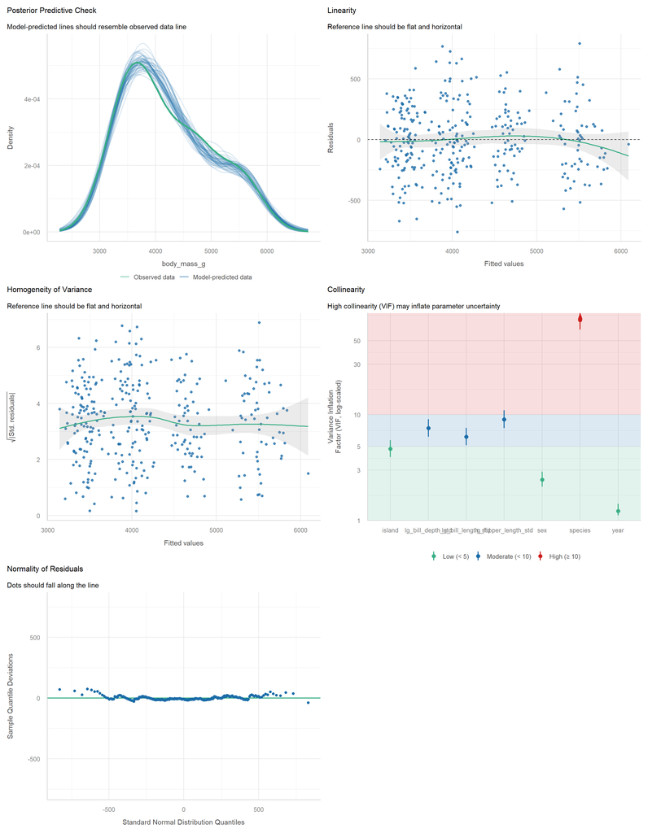

Fig.8 Residual Diagnostics for GLM

```r
check_model(model2)
```

#### RQR Plot

Observation:  
RQR plot is not perfectly linear and Shows positive tail deviation

Meaning:  
Model assumptions may not fully match the response distribution  
Positive tail suggests:  
right-skewed residuals  
possible heteroscedasticity  
Gaussian(log) may underfit heavier upper values

Potential Solution:  
Consider Gamma family with log link

Because Gamma is often better for:  
positive continuous responses  
right-skewed body mass–type data  
variance increasing with mean

#### High VIF for Species

Observation:  
Species variable has elevated VIF

Meaning:  
Species may be strongly correlated with morphology predictors Possible multicollinearity  
Species may also represent hierarchical grouping rather than purely fixed explanatory effect

```r
# Body Mass by Species


# Body Mass by flipper_length
t4 <- ggplot(penguins, aes(x = flipper_length_mm,
                            y = body_mass_g,
                            color = species)) +
  geom_point(alpha = 0.6) +
  labs(title = "Body Mass vs Flipper Length among species",
       x = "Flipper Length (mm)",
       y = "Body Mass (g)") +
  theme_minimal()

# Body Mass vs Bill Length
t5 <- ggplot(penguins, aes(x = bill_length_mm,
                            y = body_mass_g,
                            color = species)) +
  geom_point(alpha = 0.6) +
  labs(title = "Body Mass vs Bill Length among species",
       x = "Bill Length (mm)",
       y = "Body Mass (g)") +
  theme_minimal()

# Body Mass vs Bill Depth
t6 <- ggplot(penguins, aes(x = bill_depth_mm,
                            y = body_mass_g,
                            color = species)) +
  geom_point(alpha = 0.6) +
  labs(title = "Body Mass vs Bill Depth among species",
       x = "Bill Depth (mm)",
       y = "Body Mass (g)") +
  theme_minimal()
```

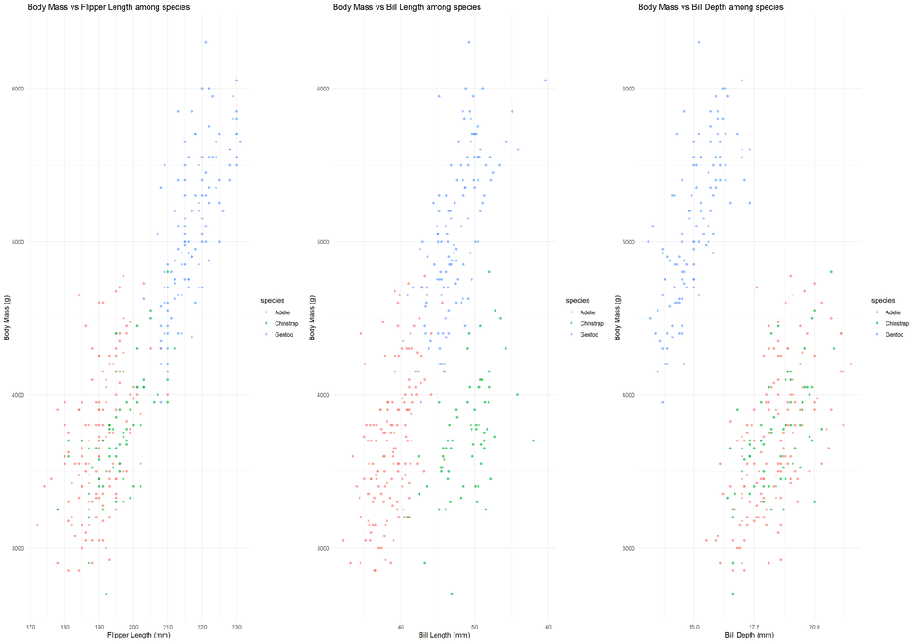

Figure 9. Explanatory Varaiables vs Response among species

```r
grid.arrange(

  t4, t5, t6,
  ncol = 3
)
```

### Generalized linear mixed model:

$$\begin{align*}
log(y)= \alpha log(X) + \beta Z +\epsilon \\
y \sim N(\mu,\sigma^2), \\
\beta \sim N(0,\sigma^2) \\
\end{align*}$$

X is the fixed effect matrix for variables lg_bill_length_std,lg_bill_depth_std, lg_flipper_length_std, sex, year, island. Z is the random effect matrix for variable species.

```r
model3=glmmTMB(body_mass_g ~ lg_bill_length_std + lg_bill_depth_std + lg_flipper_length_std+ + (1 | species) + island + year + sex,family = gaussian(link = "log"), data = penguins)

summary(model3)
```

```
##  Family: gaussian  ( log )
## Formula:
## body_mass_g ~ lg_bill_length_std + lg_bill_depth_std + lg_flipper_length_std +
##     +(1 | species) + island + year + sex
## Data: penguins
##
##       AIC       BIC    logLik -2*log(L)  df.resid
##    4739.2    4781.0   -2358.6    4717.2       322
##
## Random effects:
##
## Conditional model:
##  Groups   Name        Variance  Std.Dev.
##  species  (Intercept) 1.238e-02   0.1113
##  Residual             7.897e+04 281.0121
## Number of obs: 333, groups:  species, 3
##
## Dispersion estimate for gaussian family (sigma^2): 7.9e+04
##
## Conditional model:
##                        Estimate Std. Error z value Pr(>|z|)
## (Intercept)            8.289236   0.065517  126.52  < 2e-16 ***
## lg_bill_length_std     0.025709   0.009311    2.76  0.00576 **
## lg_bill_depth_std      0.026450   0.009724    2.72  0.00653 **
## lg_flipper_length_std  0.060289   0.010618    5.68 1.36e-08 ***
## islandDream           -0.009720   0.015528   -0.63  0.53134
## islandTorgersen       -0.018938   0.016094   -1.18  0.23933
## year2008              -0.014970   0.009576   -1.56  0.11799
## year2009              -0.022703   0.009612   -2.36  0.01818 *
## sexmale                0.090435   0.011407    7.93 2.23e-15 ***
## ---
## Signif. codes:  0 '***' 0.001 '**' 0.01 '*' 0.05 '.' 0.1 ' ' 1
```

```r
model4=glmmTMB(body_mass_g ~ lg_bill_length_std + lg_bill_depth_std + lg_flipper_length_std+ + (1 | species) + island + year + sex,family = Gamma(link = "log"), data = penguins)

summary(model4)
```

```
##  Family: Gamma  ( log )
## Formula:
## body_mass_g ~ lg_bill_length_std + lg_bill_depth_std + lg_flipper_length_std +
##     +(1 | species) + island + year + sex
## Data: penguins
##
##       AIC       BIC    logLik -2*log(L)  df.resid
##    4756.0    4797.9   -2367.0    4734.0       322
##
## Random effects:
##
## Conditional model:
##  Groups  Name        Variance Std.Dev.
##  species (Intercept) 0.01356  0.1164
## Number of obs: 333, groups:  species, 3
##
## Dispersion estimate for Gamma family (sigma^2): 0.00485
##
## Conditional model:
##                        Estimate Std. Error z value Pr(>|z|)
## (Intercept)            8.286764   0.068367  121.21  < 2e-16 ***
## lg_bill_length_std     0.026216   0.009546    2.75  0.00603 **
## lg_bill_depth_std      0.031466   0.010099    3.12  0.00183 **
## lg_flipper_length_std  0.059564   0.010701    5.57 2.60e-08 ***
## islandDream           -0.006494   0.014349   -0.45  0.65083
## islandTorgersen       -0.014164   0.014879   -0.95  0.34112
## year2008              -0.011140   0.010234   -1.09  0.27633
## year2009              -0.022217   0.010234   -2.17  0.02994 *
## sexmale                0.088921   0.011806    7.53 5.02e-14 ***
## ---
## Signif. codes:  0 '***' 0.001 '**' 0.01 '*' 0.05 '.' 0.1 ' ' 1
```

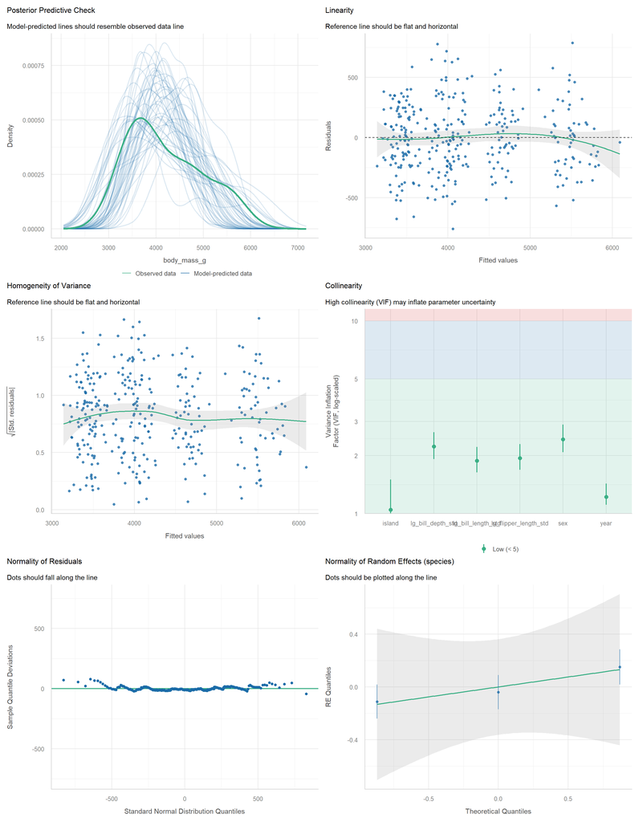

Fig.10 Residual Diagnostics for GLMM (Normal response)

```r
check_model(model3)
```

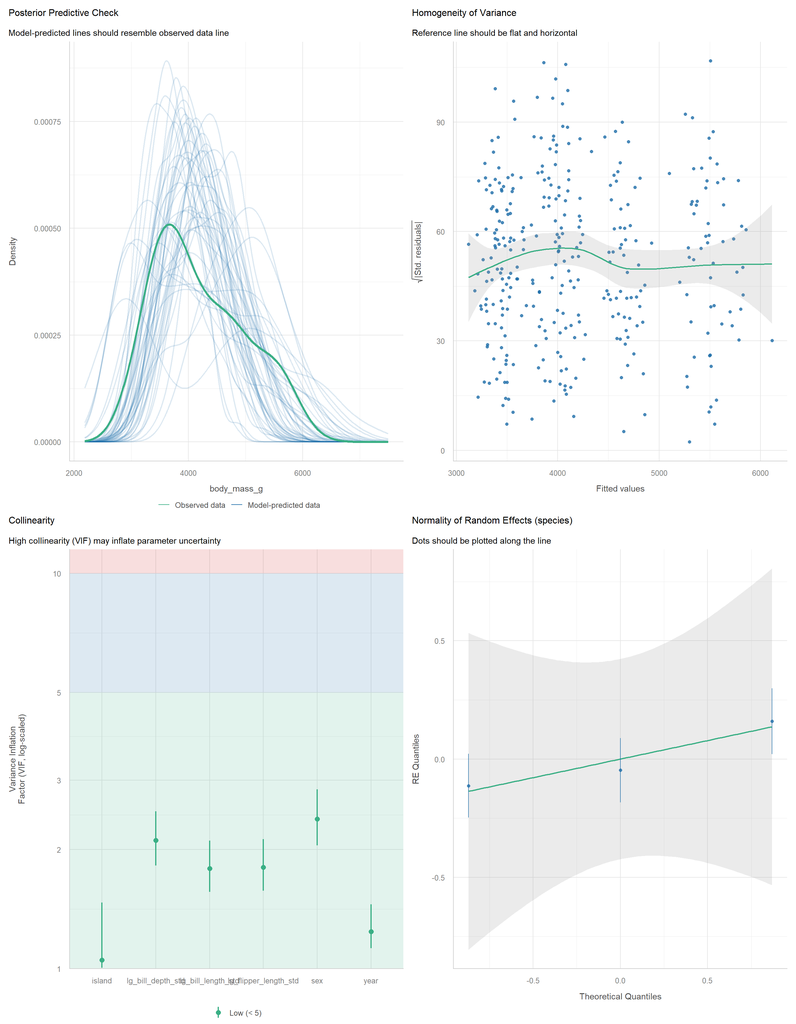

Fig.11 Residual Diagnostics for GLMM (Gamma response)

```r
check_model(model4)
```

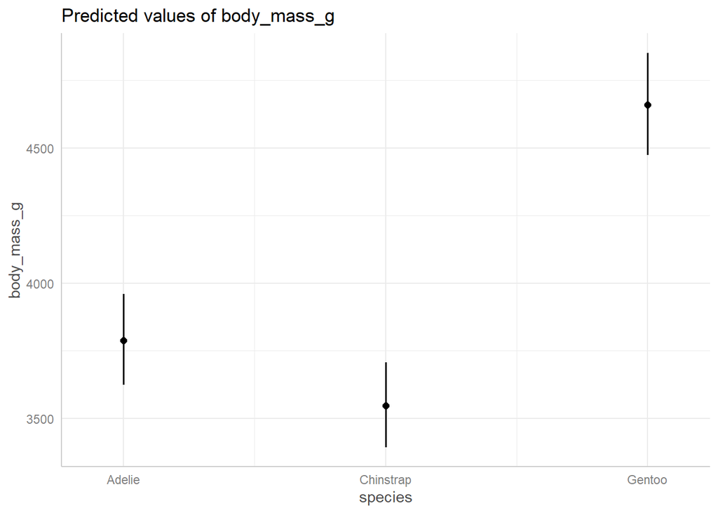

Fig.12 Predicted body mass

```r
ggeffects::ggpredict(model4, terms = c("species"), type = "random") %>% plot()
```

#### Random effect assumption (species)

The random effects diagnostic (Q–Q plot from check_model) shows that species-level random intercepts approximately follow a normal distribution, with no severe deviations.

This indicates the normality assumption for random effects is reasonable, and the grouping structure is statistically valid.

#### Random effect importance (species effect)

The estimated species variance is:

- Variance = 0.01356
- SD = 0.1164 (log scale)

Interpretation: Species differ by approximately ±12% in baseline body mass, even after accounting for morphology, sex, year, and island.

### Prediction

```r
set.seed(123)
folds <- vfold_cv(penguins, v = 3)
```

```r
# MSPE function
mspe<- function(actual, pred) {
 sqrt(mean((actual - pred)^2))
}
```

```r
form_glm  <- body_mass_g ~ lg_bill_length_std + lg_bill_depth_std +
             lg_flipper_length_std + species + island + year + sex

form_glmm_norm <- body_mass_g ~ lg_bill_length_std + lg_bill_depth_std + lg_flipper_length_std + island + year + sex +
                  (1 | species)

form_glmm_gamma <- form_glmm_norm
```

```r
# CV function
cv_model <- function(split, type){

  train <- analysis(split)
  test  <- assessment(split)

  if(type == "glm"){
    fit <- glmmTMB(form_glm,
                   family = gaussian(link="log"),
                   data = train)
    pred <- predict(fit, newdata = test, type = "response")

  } else if(type == "glmm_norm"){
    fit <- glmmTMB(form_glmm_norm,
                   family = gaussian(link="log"),
                   data = train)
    pred <- predict(fit, newdata = test, type = "response")

  } else if(type == "glmm_gamma"){
    fit <- glmmTMB(form_glmm_gamma,
                   family = Gamma(link="log"),
                   data = train)
    pred <- predict(fit, newdata = test, type = "response")
  }

  mspe(test$body_mass_g, pred)
}
```

```r
glm_rmse  <- map_dbl(folds$splits, ~cv_model(.x, "glm"))
norm_rmse <- map_dbl(folds$splits, ~cv_model(.x, "glmm_norm"))
gamma_rmse<- map_dbl(folds$splits, ~cv_model(.x, "glmm_gamma"))
```

```r
results <- tibble(
  Model = c("GLM (Gaussian log, species fixed)",
            "GLMM (Gaussian log)",
            "GLMM (Gamma log)"),
  MSPE  = c(mean(glm_rmse),
            mean(norm_rmse),
            mean(gamma_rmse)),
  SD    = c(sd(glm_rmse),
            sd(norm_rmse),
            sd(gamma_rmse))
)

results
```

```
## # A tibble: 3 × 3
##   Model                              MSPE    SD
##   <chr>                             <dbl> <dbl>
## 1 GLM (Gaussian log, species fixed)  290.  6.71
## 2 GLMM (Gaussian log)                290.  5.63
## 3 GLMM (Gamma log)                   291.  5.85
```

## 5. Conclusion

In this analysis, we compared LM, GLM, and GLMM approaches to predict penguin body mass using morphological and demographic predictors. The GLM with a log link is particularly important from a scientific perspective because it reflects a biologically meaningful multiplicative relationship between body mass and predictors such as bill and flipper measurements. This log-scale formulation is consistent with allometric scaling patterns commonly observed in biological systems, where changes in morphology are associated with proportional rather than additive changes in body mass.

The GLMM extends this framework by introducing a random intercept for species, allowing the model to account for hierarchical grouping in the data. The results show that species contributes meaningful baseline variation in body mass, indicating clear biological clustering even after controlling for morphological traits, sex, year, and island. However, despite capturing this structured variability, the GLMM does not substantially improve predictive performance compared to the GLM based on cross-validation results. This suggests that species-level variation is more important for interpretation and understanding of biological structure than for improving out-of-sample prediction in this dataset.

Cross-validation results further indicate that all models perform very similarly in terms of prediction error, with nearly identical MSPE values. The GLMM with Gaussian errors showed slightly more stable performance across folds, while the Gamma model did not lead to measurable improvements in predictive accuracy. A key limitation of this evaluation is that standard K-fold cross-validation was used without stratification by species. Given the unbalanced nature of species representation, this may introduce bias in estimating generalization error and may underrepresent the true benefit of hierarchical modelling. Therefore, a stratified or leave-one-species-out cross-validation approach would provide a more rigorous assessment of GLMM performance in future work.